# Parametric Hypothesis Tests — Part 3

Tests for Mean and Variance of Normal Populations. Mean differences.

Paulo Fagandini

Lisbon Accounting and Business School – Polytechnic University of Lisbon

2025-04-21

## Recap from Last Week

In Lecture 6, we established:

- The general framework: $H_0$ vs. $H_1$, test statistic, $\alpha$, critical region
- Type I and Type II errors, power
- The $p$-value: smallest $\alpha$ at which we reject $H_0$
- The relationship between CIs and two-tailed tests

**Today**: We apply the framework systematically to every test case in the syllabus.

## Road Map for Today

| Section | Topic |
| --- | --- |
| **3.3** | Tests for $\mu$ (Normal, $\sigma$ known and unknown) |
|  | Tests for $\sigma^2$ (Normal population) |
| **3.4** | Tests for $\mu_1 - \mu_2$ (two Normal populations) |
| **3.5** | Large-sample (asymptotic) tests: mean and proportion |

# 3.3 — Tests for Parameters of Normal Populations

## Overview

We consider a random sample $(X_1, X_2, \ldots, X_n)$ from a **Normal population** $X \sim N(\mu, \sigma)$.

We will cover four cases:

- **Case 1**: Test for $\mu$ with $\sigma$ **known**
- **Case 2**: Test for $\mu$ with $\sigma$ **unknown** (small sample)
- **Case 2’**: Test for $\mu$ with $\sigma$ **unknown** and $n > 30$
- **Case 3**: Test for $\sigma^2$ (or $\sigma$)

## Case 1: Test for $\mu$, $\sigma$ Known

**Test for $\mu$ — Normal population, $\sigma$ known**

**Test statistic:**
$$Z_0 = \frac{\bar{X} - \mu_0}{\sigma / \sqrt{n}} \underset{\text{under } H_0}{\sim} N(0, 1)$$

**Critical regions** (at significance level $\alpha$):

| $H_1$ | Rejection region |
| --- | --- |
| $\mu \neq \mu_0$ | $\\|z_{obs}\\| \geq z_{\alpha/2}$ |
| $\mu > \mu_0$ | $z_{obs} \geq z_{\alpha}$ |
| $\mu < \mu_0$ | $z_{obs} \leq -z_{\alpha}$ |

Recall: $z_{\alpha}$ is the value such that $P(Z > z_{\alpha}) = \alpha$, from the Standard Normal table.

## Example 1: Test for $\mu$, $\sigma$ known

The nominal capacity of a soft drink bottle is 330 mL. The filling process has $\sigma = 5$ mL. A random sample of $n = 40$ bottles has $\bar{x} = 328.2$ mL. At $\alpha = 0.05$, test whether the mean capacity differs from 330 mL.

## Example 1: Solution

**Hypotheses**: $H_0: \mu = 330$ vs. $H_1: \mu \neq 330$ (two-tailed)

**Test statistic**: $Z_0 = \frac{\bar{X} - 330}{5/\sqrt{40}} \sim N(0,1)$

**Observed value:**
$$z_{obs} = \frac{328.2 - 330}{5/\sqrt{40}} = \frac{-1.8}{0.7906} \approx -2.28$$

**Rejection region** (two-tailed, $\alpha = 0.05$):
$$|z_{obs}| \geq z_{0.025} = 1.96$$

Since $|-2.28| = 2.28 > 1.96$, we **reject $H_0$**.

**$p$-value**: $p = 2 \times P(Z \geq 2.28) = 2 \times (1 - 0.9887) = 2 \times 0.0113 = 0.0226$

## Case 2: Test for $\mu$, $\sigma$ Unknown

**Test for $\mu$ — Normal population, $\sigma$ unknown**

**Test statistic:**
$$T_0 = \frac{\bar{X} - \mu_0}{S' / \sqrt{n}} \underset{\text{under } H_0}{\sim} t_{(n-1)}$$

**Critical regions** (at significance level $\alpha$):

| $H_1$ | Rejection region |
| --- | --- |
| $\mu \neq \mu_0$ | $\\|t_{obs}\\| \geq t_{\alpha/2,(n-1)}$ |
| $\mu > \mu_0$ | $t_{obs} \geq t_{\alpha,(n-1)}$ |
| $\mu < \mu_0$ | $t_{obs} \leq -t_{\alpha,(n-1)}$ |

Recall: $S'$ is the corrected sample standard deviation, and $t_{\alpha,(\nu)}$ is from Table 7 ($t$-Student).

## Example 2: Test for $\mu$, $\sigma$ unknown

An engineer suspects that the mean weight of packages produced by a machine exceeds the nominal value of 100 g. A random sample of $n = 20$ packages from a Normal population gives $\bar{x} = 101$ g and $s' = 3$ g.

Test at $\alpha = 0.05$.

## Example 2: Solution

**Hypotheses**: $H_0: \mu \leq 100$ vs. $H_1: \mu > 100$ (right-tailed)

**Test statistic**: $T_0 = \frac{\bar{X} - 100}{S'/\sqrt{20}} \sim t_{(19)}$

**Observed value:**
$$t_{obs} = \frac{101 - 100}{3/\sqrt{20}} = \frac{1}{0.6708} \approx 1.49$$

**Rejection region** (right-tailed, $\alpha = 0.05$):
$$t_{obs} \geq t_{0.05,(19)} = 1.729$$

(Table 7)

Since $1.49 < 1.729$, we **do not reject $H_0$**.

**Conclusion**: At 5%, there is **insufficient evidence** that the mean weight exceeds 100 g.

## Case 2’: Test for $\mu$, $\sigma$ Unknown, $n > 30$

**Test for $\mu$ — Normal population, $\sigma$ unknown, large sample ($n > 30$)**

When $n > 30$, $S'$ approximates $\sigma$ well and the $t$-distribution approaches the Standard Normal:

$$Z_0 = \frac{\bar{X} - \mu_0}{S' / \sqrt{n}} \underset{\text{under } H_0}{\dot{\sim}} N(0, 1)$$

The critical regions are the same as in Case 1, using $z_{\alpha}$ and $z_{\alpha/2}$ from the Normal table.

> This is the same approach as in Case 1, but replacing $\sigma$ by $s'$. The approximation is justified by the CLT and by the fact that $t_{(\nu)} \to N(0,1)$ as $\nu \to \infty$.

## Case 3: Test for $\sigma^2$ (Variance)

**Test for $\sigma^2$ — Normal population**

**Test statistic:**
$$Q_0 = \frac{(n-1)S'^2}{\sigma_0^2} \underset{\text{under } H_0}{\sim} \chi^2_{(n-1)}$$

**Critical regions** (at significance level $\alpha$):

| $H_1$ | Rejection region |
| --- | --- |
| $\sigma^2 \neq \sigma_0^2$ | $q_{obs} \leq q_{1-\alpha/2}$ or $q_{obs} \geq q_{\alpha/2}$ |
| $\sigma^2 > \sigma_0^2$ | $q_{obs} \geq q_{\alpha}$ |
| $\sigma^2 < \sigma_0^2$ | $q_{obs} \leq q_{1-\alpha}$ |

Here $q_{\alpha}$ denotes the value from the $\chi^2$ table (Table 6) such that $P(Q > q_{\alpha}) = \alpha$.

## Important: The $\chi^2$ Distribution is Not Symmetric

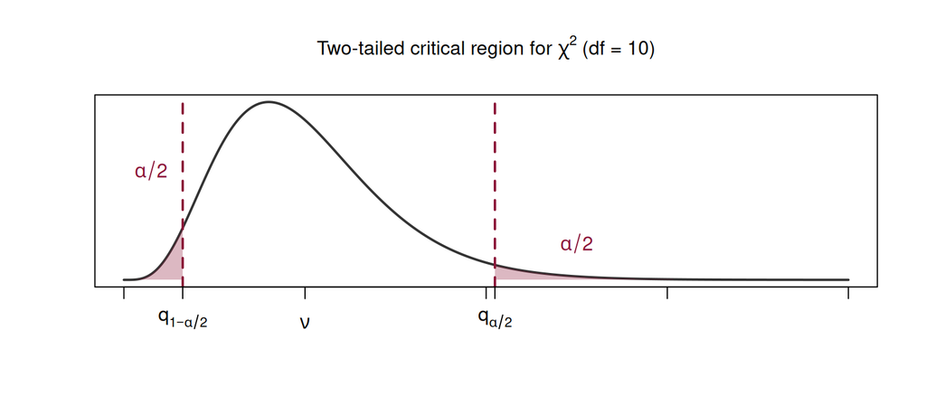

Because the $\chi^2$ distribution is **right-skewed**, the two-tailed rejection region is **not symmetric** around the center. The lower critical value is $q_{1-\alpha/2}$ and the upper is $q_{\alpha/2}$.

## Example 3: Test for $\sigma^2$

Consider the test: $H_0: \sigma^2 \geq 10$ vs. $H_1: \sigma^2 < 10$, with $n = 20$ from a Normal population and $s'^2 = 9$ (i.e., $s' = 3$).

Test at $\alpha = 0.05$.

## Example 3: Solution

**Test statistic:**
$$Q_0 = \frac{(n-1)S'^2}{\sigma_0^2} \underset{\text{under } H_0}{\sim} \chi^2_{(19)}$$

**Observed value:**
$$q_{obs} = \frac{(20-1) \times 9}{10} = \frac{171}{10} = 17.1$$

**Rejection region** (left-tailed, $\alpha = 0.05$):

We need $q_{1-\alpha} = q_{0.95}$ from the $\chi^2$ table with 19 d.f.

From Table 6: $q_{0.95,(19)} = 10.117$.

Rejection region: $\left[0\,;\, 10.117\right]$.

Since $q_{obs} = 17.1 > 10.117$, we **do not reject $H_0$**.

## Summary of Cases — Section 3.3

| Parameter | $\sigma$ | Test Stat. | Distribution | Table |
| --- | --- | --- | --- | --- |
| $\mu$ | known | $Z_0 = \frac{\bar{X}-\mu_0}{\sigma/\sqrt{n}}$ | $N(0,1)$ | Normal |
| $\mu$ | unknown, $n\leq 30$ | $T_0 = \frac{\bar{X}-\mu_0}{S'/\sqrt{n}}$ | $t_{(n-1)}$ | Table 7 |
| $\mu$ | unknown, $n > 30$ | $Z_0 = \frac{\bar{X}-\mu_0}{S'/\sqrt{n}}$ | $\dot\sim N(0,1)$ | Normal |
| $\sigma^2$ | — | $Q_0 = \frac{(n-1)S'^2}{\sigma_0^2}$ | $\chi^2_{(n-1)}$ | Table 6 |

This mirrors the cases from interval estimation — the pivot variables are the same.

## Practice Exercise A

A quality inspector measures the temperature of a chemical process. Historical data show $\sigma = 2.5°$C. A random sample of $n = 16$ measurements gives $\bar{x} = 98.3°$C.

1. Test $H_0: \mu = 100$ vs. $H_1: \mu \neq 100$ at $\alpha = 0.01$.
2. Compute the $p$-value.

## Practice Exercise A: Solution

**a)** $Z_0 = \frac{\bar{X} - 100}{2.5/\sqrt{16}} \sim N(0,1)$

$$z_{obs} = \frac{98.3 - 100}{2.5/4} = \frac{-1.7}{0.625} = -2.72$$

Rejection region (two-tailed, $\alpha = 0.01$): $|z_{obs}| \geq z_{0.005} = 2.576$

Since $|-2.72| = 2.72 > 2.576$, we **reject $H_0$**.

**b)** $p = 2 \times P(Z \geq 2.72) = 2 \times (1 - 0.9967) = 2 \times 0.0033 = 0.0066$

**Conclusion**: At 1%, there is evidence that the process temperature differs from 100°C.

## Practice Exercise B

From a Normal population, a sample of $n = 15$ observations gives $s' = 5.04$.

Test $H_0: \sigma^2 = 16$ vs. $H_1: \sigma^2 \neq 16$ at $\alpha = 0.10$.

## Practice Exercise B: Solution

**Test statistic:**
$$Q_0 = \frac{(n-1)S'^2}{\sigma_0^2} \sim \chi^2_{(14)}$$

$$q_{obs} = \frac{14 \times (5.04)^2}{16} = \frac{14 \times 25.4016}{16} = \frac{355.62}{16} \approx 22.23$$

**Rejection region** (two-tailed, $\alpha = 0.10$):

From Table 6, $\nu = 14$: $q_{0.95,(14)} = 6.571$ and $q_{0.05,(14)} = 23.685$

Reject if $q_{obs} \leq 6.571$ or $q_{obs} \geq 23.685$.

Since $6.571 < 22.23 < 23.685$, we **do not reject $H_0$**.

**Conclusion**: At 10%, there is no evidence that $\sigma^2 \neq 16$.

## Quick Recap Before the Break

**What we covered (Section 3.3)**

- **Case 1**: Test for $\mu$ with $\sigma$ known → $Z_0 \sim N(0,1)$
- **Case 2**: Test for $\mu$ with $\sigma$ unknown → $T_0 \sim t_{(n-1)}$
- **Case 2’**: Test for $\mu$ with $\sigma$ unknown, $n>30$ → $Z_0 \dot\sim N(0,1)$
- **Case 3**: Test for $\sigma^2$ → $Q_0 \sim \chi^2_{(n-1)}$

# 3.4 — Tests for the Difference of Means

## Setup

We have **two independent** Normal populations:

$$X_1 \sim N(\mu_1, \sigma_1) \qquad X_2 \sim N(\mu_2, \sigma_2)$$

Two independent random samples:

- From population 1: $n_1$ observations → $\bar{X}_1$, $S'^2_1$
- From population 2: $n_2$ observations → $\bar{X}_2$, $S'^2_2$

**Goal**: Test hypotheses about $\mu_1 - \mu_2$ (usually testing if $\mu_1 - \mu_2 = 0$, i.e., if the two means are equal).

## The General Hypotheses

| $H_0$ | $H_1$ | Type |
| --- | --- | --- |
| $\mu_1 - \mu_2 = d_0$ | $\mu_1 - \mu_2 \neq d_0$ | Two-tailed |
| $\mu_1 - \mu_2 \leq d_0$ | $\mu_1 - \mu_2 > d_0$ | Right-tailed |
| $\mu_1 - \mu_2 \geq d_0$ | $\mu_1 - \mu_2 < d_0$ | Left-tailed |

Often $d_0 = 0$, i.e., we test whether the two population means are equal.

## Case A: Both $\sigma_1$ and $\sigma_2$ Known

**Test for $\mu_1 - \mu_2$ — variances known**

**Test statistic:**
$$Z_0 = \frac{(\bar{X}_1 - \bar{X}_2) - d_0}{\sqrt{\dfrac{\sigma_1^2}{n_1} + \dfrac{\sigma_2^2}{n_2}}} \underset{\text{under } H_0}{\sim} N(0, 1)$$

Critical regions use $z_{\alpha}$ and $z_{\alpha/2}$ from the Normal table, as in the one-sample case.

## Case B: Variances Unknown but Equal ($\sigma_1^2 = \sigma_2^2$)

**Test for $\mu_1 - \mu_2$ — variances unknown, assumed equal**

We estimate the **common variance** using the **pooled estimator**:

$$S_p'^2 = \frac{(n_1 - 1)S'^2_1 + (n_2 - 1)S'^2_2}{n_1 + n_2 - 2}$$

**Test statistic:**
$$T_0 = \frac{(\bar{X}_1 - \bar{X}_2) - d_0}{S'_p\sqrt{\dfrac{1}{n_1} + \dfrac{1}{n_2}}} \underset{\text{under } H_0}{\sim} t_{(n_1 + n_2 - 2)}$$

The degrees of freedom are $\nu = n_1 + n_2 - 2$. Critical values from Table 7.

## When Can We Assume Equal Variances?

In practice, the assumption $\sigma_1^2 = \sigma_2^2$ can be tested using an **$F$-test** (not in our syllabus), or it may be given in the problem statement.

**Practical rule**: If the ratio of the larger sample variance to the smaller is less than about 2–3, the equal-variance assumption is often reasonable.

> When the problem says “assume equal variances” or “assume $\sigma_1 = \sigma_2$”, use the pooled estimator.

## Example 4: Difference of Means (Equal Variances)

Two production lines manufacture the same component. To compare average lengths, independent random samples are taken:

- **Line 1**: $n_1 = 12$, $\bar{x}_1 = 50.3$ mm, $s'_1 = 1.2$ mm
- **Line 2**: $n_2 = 15$, $\bar{x}_2 = 49.7$ mm, $s'_2 = 1.4$ mm

Assuming equal population variances and Normal populations, test whether the mean lengths differ at $\alpha = 0.05$.

## Example 4: Solution — Step 1

**Hypotheses**: $H_0: \mu_1 - \mu_2 = 0$ vs. $H_1: \mu_1 - \mu_2 \neq 0$ (two-tailed)

**Pooled variance:**
$$s_p'^2 = \frac{(12-1)(1.2)^2 + (15-1)(1.4)^2}{12 + 15 - 2} = \frac{11 \times 1.44 + 14 \times 1.96}{25}$$

$$= \frac{15.84 + 27.44}{25} = \frac{43.28}{25} = 1.7312$$

$$s'_p = \sqrt{1.7312} \approx 1.3157$$

## Example 4: Solution — Step 2

**Test statistic**: $T_0 \sim t_{(25)}$

$$t_{obs} = \frac{(50.3 - 49.7) - 0}{1.3157 \sqrt{\frac{1}{12} + \frac{1}{15}}} = \frac{0.6}{1.3157 \times \sqrt{0.0833 + 0.0667}}$$

$$= \frac{0.6}{1.3157 \times \sqrt{0.15}} = \frac{0.6}{1.3157 \times 0.3873} = \frac{0.6}{0.5095} \approx 1.18$$

## Example 4: Solution — Step 3

**Rejection region** (two-tailed, $\alpha = 0.05$, $\nu = 25$):

From Table 7: $t_{0.025,(25)} = 2.060$

Reject if $|t_{obs}| \geq 2.060$.

Since $|1.18| = 1.18 < 2.060$, we **do not reject $H_0$**.

**Conclusion**: At 5%, there is **no evidence** of a difference in mean lengths between the two production lines.

## Case C: Variances Unknown, Large Samples

**Test for $\mu_1 - \mu_2$ — variances unknown, $n_1 > 30$ and $n_2 > 30$**

When both samples are large, the CLT applies and we can use:

$$Z_0 = \frac{(\bar{X}_1 - \bar{X}_2) - d_0}{\sqrt{\dfrac{S'^2_1}{n_1} + \dfrac{S'^2_2}{n_2}}} \underset{\text{under } H_0}{\dot{\sim}} N(0, 1)$$

No assumption about equal variances is needed.

## Example 5: Difference of Means (Large Samples)

A company wants to compare the average monthly sales (in thousands of euros) of two regions:

- **Region A**: $n_1 = 50$, $\bar{x}_1 = 87.3$, $s'_1 = 12.5$
- **Region B**: $n_2 = 45$, $\bar{x}_2 = 82.1$, $s'_2 = 14.8$

Test $H_0: \mu_1 \leq \mu_2$ vs. $H_1: \mu_1 > \mu_2$ at $\alpha = 0.05$.

## Example 5: Solution

**Hypotheses**: $H_0: \mu_1 - \mu_2 \leq 0$ vs. $H_1: \mu_1 - \mu_2 > 0$ (right-tailed)

$$z_{obs} = \frac{(87.3 - 82.1) - 0}{\sqrt{\frac{(12.5)^2}{50} + \frac{(14.8)^2}{45}}} = \frac{5.2}{\sqrt{\frac{156.25}{50} + \frac{219.04}{45}}}$$

$$= \frac{5.2}{\sqrt{3.125 + 4.868}} = \frac{5.2}{\sqrt{7.993}} = \frac{5.2}{2.827} \approx 1.84$$

**Rejection region** (right-tailed, $\alpha = 0.05$): $z_{obs} \geq z_{0.05} = 1.645$

Since $1.84 > 1.645$, we **reject $H_0$**.

**$p$-value**: $p = P(Z > 1.84) = 1 - \Phi(1.84) = 1 - 0.9671 = 0.0329$

## Summary: Tests for $\mu_1 - \mu_2$

| Case | Conditions | Test Statistic | Distribution |
| --- | --- | --- | --- |
| A | $\sigma_1, \sigma_2$ known | $Z_0$ with $\sigma_1, \sigma_2$ | $N(0,1)$ |
| B | $\sigma_1, \sigma_2$ unknown, equal | $T_0$ with $S'_p$ | $t_{(n_1+n_2-2)}$ |
| C | Large samples ($n_1, n_2 > 30$) | $Z_0$ with $S'_1, S'_2$ | $\dot\sim N(0,1)$ |

# 3.5 — Large-Sample Tests (Asymptotic Normality)

## Motivation

So far, we assumed **Normal populations** (except for Case 2’ and Case C, where the CLT helped).

What if we do **not know** the population distribution, but have a **large sample** ($n > 30$)?

By the **Central Limit Theorem**, the sampling distribution of $\bar{X}$ is approximately Normal, regardless of the population distribution.

This allows us to perform tests even without the Normality assumption.

## Test for $\mu$ — Large Sample, Non-Normal Population

**Test for $\mu$ — large sample, any distribution**

If $n > 30$, by the CLT:

$$Z_0 = \frac{\bar{X} - \mu_0}{S' / \sqrt{n}} \underset{\text{under } H_0}{\dot{\sim}} N(0, 1)$$

This is the **same formula** as Case 2’ (Normal population, $\sigma$ unknown, $n > 30$), but now the Normality assumption on the population is relaxed.

The critical regions and $p$-value calculations use the Standard Normal table.

## Example 6: Large-Sample Test for $\mu$

A logistics company records the delivery time for packages. The distribution is unknown (likely right-skewed). A random sample of $n = 100$ deliveries gives $\bar{x} = 3.2$ days and $s' = 0.8$ days.

Test $H_0: \mu \leq 3$ vs. $H_1: \mu > 3$ at $\alpha = 0.05$.

## Example 6: Solution

Even though the population is not Normal, $n = 100 > 30$, so the CLT applies.

$$z_{obs} = \frac{3.2 - 3}{0.8/\sqrt{100}} = \frac{0.2}{0.08} = 2.50$$

**Rejection region** (right-tailed, $\alpha = 0.05$): $z_{obs} \geq 1.645$

Since $2.50 > 1.645$, we **reject $H_0$**.

**$p$-value**: $p = P(Z > 2.50) = 1 - \Phi(2.50) = 1 - 0.9938 = 0.0062$

Strong evidence that the mean delivery time exceeds 3 days.

## Test for a Proportion $p$ — Bernoulli Population

**Test for $p$ — large sample from a Bernoulli population**

Let $X \sim \text{Bernoulli}(p)$. The sample proportion is $\hat{p} = X/n$, where $X = \sum_{i=1}^n X_i$.

For large $n$ (typically $np_0 \geq 5$ and $n(1-p_0) \geq 5$), by the CLT:

$$Z_0 = \frac{\hat{p} - p_0}{\sqrt{\dfrac{p_0(1 - p_0)}{n}}} \underset{\text{under } H_0}{\dot{\sim}} N(0, 1)$$

> **Note**: Under $H_0$, we use $p_0$ (not $\hat{p}$) in the denominator, because we assume $H_0$ is true when computing the test statistic.

## Example 7: Test for a Proportion

A company claims that at most 5% of its products are defective. In a random sample of $n = 200$ items, 15 are found to be defective.

Test the company’s claim at $\alpha = 0.05$.

## Example 7: Solution

**Hypotheses**: $H_0: p \leq 0.05$ vs. $H_1: p > 0.05$ (right-tailed)

$\hat{p} = 15/200 = 0.075$, $p_0 = 0.05$

**Checking conditions**: $np_0 = 200 \times 0.05 = 10 \geq 5$ ✓ and $n(1-p_0) = 190 \geq 5$ ✓

$$z_{obs} = \frac{0.075 - 0.05}{\sqrt{\frac{0.05 \times 0.95}{200}}} = \frac{0.025}{\sqrt{\frac{0.0475}{200}}} = \frac{0.025}{\sqrt{0.0002375}}$$

$$= \frac{0.025}{0.01541} \approx 1.62$$

## Example 7: Solution (cont.)

**Rejection region** (right-tailed, $\alpha = 0.05$): $z_{obs} \geq 1.645$

Since $1.62 < 1.645$, we **do not reject $H_0$**.

**$p$-value**: $p = P(Z > 1.62) = 1 - \Phi(1.62) = 1 - 0.9474 = 0.0526$

**Conclusion**: At 5%, there is **marginal** but insufficient evidence to reject the company’s claim. The $p$-value ($0.0526$) is just barely above $\alpha$.

> This is a “borderline” case. At $\alpha = 0.10$ we would reject $H_0$.

## Example 8: Test for Proportion (Two-tailed)

In a survey of $n = 400$ voters, 224 favor a certain policy. Test whether the true proportion differs from 50% at $\alpha = 0.01$.

## Example 8: Solution

$H_0: p = 0.50$ vs. $H_1: p \neq 0.50$ (two-tailed)

$\hat{p} = 224/400 = 0.56$

$$z_{obs} = \frac{0.56 - 0.50}{\sqrt{\frac{0.50 \times 0.50}{400}}} = \frac{0.06}{\sqrt{0.000625}} = \frac{0.06}{0.025} = 2.40$$

**Rejection region** (two-tailed, $\alpha = 0.01$): $|z_{obs}| \geq z_{0.005} = 2.576$

Since $|2.40| = 2.40 < 2.576$, we **do not reject $H_0$** at 1%.

**$p$-value**: $p = 2 \times P(Z > 2.40) = 2 \times 0.0082 = 0.0164$

At $\alpha = 0.05$ we **would** reject. At $\alpha = 0.01$ we do **not**.

# Comprehensive Summary

## All Test Cases — Complete Reference

| # | Parameter | Conditions | Test Statistic | Distribution |
| --- | --- | --- | --- | --- |
| 1 | $\mu$ | Normal, $\sigma$ known | $\frac{\bar{X}-\mu_0}{\sigma/\sqrt{n}}$ | $N(0,1)$ |
| 2 | $\mu$ | Normal, $\sigma$ unknown | $\frac{\bar{X}-\mu_0}{S'/\sqrt{n}}$ | $t_{(n-1)}$ |
| 2’ | $\mu$ | Normal, $\sigma$ unknown, $n>30$ | $\frac{\bar{X}-\mu_0}{S'/\sqrt{n}}$ | $\dot\sim N(0,1)$ |
| 3 | $\sigma^2$ | Normal | $\frac{(n-1)S'^2}{\sigma_0^2}$ | $\chi^2_{(n-1)}$ |
| 4a | $\mu_1-\mu_2$ | Normal, $\sigma_1,\sigma_2$ known | $\frac{(\bar{X}_1-\bar{X}_2)-d_0}{\sqrt{\sigma_1^2/n_1+\sigma_2^2/n_2}}$ | $N(0,1)$ |
| 4b | $\mu_1-\mu_2$ | Normal, $\sigma_1=\sigma_2$ unknown | $\frac{(\bar{X}_1-\bar{X}_2)-d_0}{S'_p\sqrt{1/n_1+1/n_2}}$ | $t_{(n_1+n_2-2)}$ |
| 4c | $\mu_1-\mu_2$ | Large samples | $\frac{(\bar{X}_1-\bar{X}_2)-d_0}{\sqrt{S'^2_1/n_1+S'^2_2/n_2}}$ | $\dot\sim N(0,1)$ |
| 5 | $\mu$ | Any distrib., $n > 30$ | $\frac{\bar{X}-\mu_0}{S'/\sqrt{n}}$ | $\dot\sim N(0,1)$ |
| 6 | $p$ | Bernoulli, large $n$ | $\frac{\hat{p}-p_0}{\sqrt{p_0(1-p_0)/n}}$ | $\dot\sim N(0,1)$ |

## Critical Regions — Quick Reference

For a test statistic $T$ with observed value $t_{obs}$:

| $H_1$ | Rejection region | $p$-value |
| --- | --- | --- |
| $\theta \neq \theta_0$ | $\\|t_{obs}\\| \geq c_{\alpha/2}$ | $2 \times P(T \geq \\|t_{obs}\\|)$ |
| $\theta > \theta_0$ | $t_{obs} \geq c_{\alpha}$ | $P(T \geq t_{obs})$ |
| $\theta < \theta_0$ | $t_{obs} \leq -c_{\alpha}$ (or $\leq c_{1-\alpha}$ for $\chi^2$) | $P(T \leq t_{obs})$ |

$c_{\alpha}$ is the critical value at level $\alpha$ from the appropriate table ($z_{\alpha}$, $t_{\alpha,(\nu)}$, or $q_{\alpha,(\nu)}$).

## The General Procedure — Revisited

**Step-by-step (for any case)**

1. **Identify** the parameter, population(s), and what is known/unknown
2. **State** $H_0$ and $H_1$
3. **Choose** $\alpha$
4. **Select** the appropriate test statistic (from the summary table)
5. **Determine** the critical region (using the correct table and type of test)
6. **Compute** $t_{obs}$ (and the $p$-value, if requested)
7. **Decide**: reject or do not reject $H_0$
8. **Conclude** in context

# Additional Practice

## Exercise C

In a random sample of $n = 250$ consumers surveyed, 75 stated they prefer brand A.

1. Test $H_0: p = 0.35$ vs. $H_1: p \neq 0.35$ at $\alpha = 0.05$.
2. Compute the $p$-value.

## Exercise C: Solution

$\hat{p} = 75/250 = 0.30$, $p_0 = 0.35$

$$z_{obs} = \frac{0.30 - 0.35}{\sqrt{\frac{0.35 \times 0.65}{250}}} = \frac{-0.05}{\sqrt{0.00091}} = \frac{-0.05}{0.03017} \approx -1.66$$

**Rejection region** (two-tailed, $\alpha = 0.05$): $|z_{obs}| \geq 1.96$

Since $|-1.66| = 1.66 < 1.96$, we **do not reject $H_0$**.

**$p$-value**: $p = 2 \times P(Z \geq 1.66) = 2 \times (1 - 0.9515) = 2 \times 0.0485 = 0.0970$

No evidence at 5% that $p \neq 0.35$.

## Exercise D

Two factories produce steel rods. Quality control takes samples:

- **Factory 1**: $n_1 = 10$, $\bar{x}_1 = 502.1$ mm, $s'_1 = 4.5$ mm
- **Factory 2**: $n_2 = 12$, $\bar{x}_2 = 498.3$ mm, $s'_2 = 5.1$ mm

Assume Normal populations with equal variances. Test whether Factory 1 produces longer rods at $\alpha = 0.05$.

## Exercise D: Solution

$H_0: \mu_1 - \mu_2 \leq 0$ vs. $H_1: \mu_1 - \mu_2 > 0$ (right-tailed)

**Pooled variance:**
$$s'^2_p = \frac{9 \times (4.5)^2 + 11 \times (5.1)^2}{10 + 12 - 2} = \frac{9 \times 20.25 + 11 \times 26.01}{20} = \frac{182.25 + 286.11}{20} = \frac{468.36}{20} = 23.418$$

$$s'_p = \sqrt{23.418} \approx 4.839$$

$$t_{obs} = \frac{(502.1 - 498.3) - 0}{4.839\sqrt{\frac{1}{10} + \frac{1}{12}}} = \frac{3.8}{4.839 \times \sqrt{0.1833}} = \frac{3.8}{4.839 \times 0.4282} = \frac{3.8}{2.072} \approx 1.83$$

## Exercise D: Solution (cont.)

**Rejection region** (right-tailed, $\alpha = 0.05$, $\nu = 20$):

From Table 7: $t_{0.05,(20)} = 1.725$

Since $1.83 > 1.725$, we **reject $H_0$**.

**$p$-value**: From Table 7, $t_{0.05,(20)} = 1.725$ and $t_{0.025,(20)} = 2.086$.

Since $1.725 < 1.83 < 2.086$: $0.025 < p < 0.05$.

**Conclusion**: At 5%, there is evidence that Factory 1 produces longer rods on average than Factory 2.

## Summary of Today’s Lecture

**Key takeaways — Lecture 7**

- **Section 3.3**: Tests for $\mu$ ($\sigma$ known/unknown) and $\sigma^2$ of Normal populations use the same pivot variables as confidence intervals ($Z$, $T$, $Q$)
- **Section 3.4**: Tests for $\mu_1 - \mu_2$ require identifying whether variances are known, unknown-but-equal (pooled), or whether samples are large
- **Section 3.5**: Large-sample tests ($n > 30$) work for any distribution thanks to the CLT; tests for proportions use $\hat{p}$ and $p_0$
- In **all cases**, the procedure is the same 8-step process
- The $p$-value provides the strength of evidence and can be used alongside (or instead of) the critical region approach

## What’s Next

The second midterm covers Topics 2.2, 3, and 4.

Next: **Topic 4 — The Linear Regression Model**.

## Disclaimer

These slides are a free adaptation of the course material for Estatística II by Prof. Teresa Ferreira and Prof. Sandra Custódio from the Lisbon Accounting and Business School — Polytechnic University of Lisbon.

Primary reference: Newbold, P., Carlson, W. & Thorne, B. — *Statistics for Business and Economics*, Global Edition.